# Song Recommendation System

## Methodologies

### Data splitting

We are going to **split** the data before applying any algorithms since it prevents `data leakage`.

```python
from sklearn.model_selection import train_test_split

#Split 90:10, since our dataset is small, it is better to split 90:10
songs_train, songs_test = train_test_split(my_spotify_data, test_size=0.1, random_state=2002)
```

```python
songs_train.head(5)
```

| song name | danceability | energy | loudness | speechiness | acousticness | instrumentalness | liveness | valence | tempo | duration_ms | time_signature |
| --- | --- | --- | --- | --- | --- | --- | --- | --- | --- | --- | --- |
| I Can't Win | 0.472 | 0.746 | -4.816 | 0.0321 | 0.005810 | 0.66300 | 0.0999 | 0.403 | 97.440 | 162040 | 4 |
| Little Girl (feat. Julian Casablancas) | 0.540 | 0.912 | -5.678 | 0.0376 | 0.000108 | 0.00298 | 0.1340 | 0.839 | 146.033 | 272933 | 4 |
| Damage, Inc. | 0.326 | 0.848 | -10.567 | 0.1670 | 0.000467 | 0.46600 | 0.1340 | 0.143 | 91.671 | 332465 | 4 |
| Holy Ground (Taylor's Version) | 0.622 | 0.809 | -5.623 | 0.0638 | 0.028800 | 0.00218 | 0.1090 | 0.511 | 156.894 | 202960 | 4 |
| Enter Sandman | 0.577 | 0.828 | -8.691 | 0.0298 | 0.002130 | 0.01140 | 0.0581 | 0.604 | 123.257 | 331267 | 4 |

```python
songs_train.describe()
```

|  | danceability | energy | loudness | speechiness | acousticness | instrumentalness | liveness | valence | tempo | duration_ms | time_signature |
| --- | --- | --- | --- | --- | --- | --- | --- | --- | --- | --- | --- |
| count | 90.000000 | 90.000000 | 90.000000 | 90.000000 | 90.000000 | 90.000000 | 90.000000 | 90.000000 | 90.000000 | 90.000000 | 90.000000 |
| mean | 0.513000 | 0.713933 | -6.946544 | 0.062124 | 0.152211 | 0.130105 | 0.161226 | 0.453663 | 121.539644 | 251860.566667 | 3.955556 |
| std | 0.131923 | 0.215500 | 2.865966 | 0.065271 | 0.257284 | 0.229881 | 0.095530 | 0.226643 | 25.492877 | 87214.858885 | 0.255770 |
| min | 0.216000 | 0.161000 | -15.434000 | 0.025500 | 0.000009 | 0.000000 | 0.039000 | 0.038200 | 72.062000 | 145213.000000 | 3.000000 |
| 25% | 0.426750 | 0.585500 | -8.816250 | 0.033425 | 0.000480 | 0.000052 | 0.097850 | 0.309500 | 103.576000 | 194463.500000 | 4.000000 |
| 50% | 0.514000 | 0.772000 | -5.955500 | 0.040650 | 0.012750 | 0.007495 | 0.124500 | 0.473500 | 119.773000 | 221293.500000 | 4.000000 |
| 75% | 0.621250 | 0.893000 | -4.838500 | 0.063875 | 0.200750 | 0.099250 | 0.207250 | 0.604750 | 137.521000 | 274513.250000 | 4.000000 |
| max | 0.798000 | 0.994000 | -2.293000 | 0.464000 | 0.967000 | 0.857000 | 0.483000 | 0.964000 | 189.286000 | 588667.000000 | 5.000000 |

We are going to put the songs into different clusters. We are going to use the K-Means Clustering Algorithm. K-Means requires standardized data. As we can see from the above table, this data set is not standardized. We can use the StandardScaler() class and its methods to standardize this data.

```python
from sklearn.preprocessing import StandardScaler
from sklearn import set_config
set_config(transform_output="pandas")

scaler = StandardScaler()
songs_train_scaled = scaler.fit_transform(songs_train)
```

```python
songs_train_scaled.describe()
```

|  | danceability | energy | loudness | speechiness | acousticness | instrumentalness | liveness | valence | tempo | duration_ms | time_signature |
| --- | --- | --- | --- | --- | --- | --- | --- | --- | --- | --- | --- |
| count | 9.000000e+01 | 9.000000e+01 | 9.000000e+01 | 9.000000e+01 | 9.000000e+01 | 9.000000e+01 | 9.000000e+01 | 9.000000e+01 | 9.000000e+01 | 9.000000e+01 | 9.000000e+01 |
| mean | -6.476301e-17 | -4.033810e-16 | -6.167906e-17 | 7.463166e-17 | 4.564250e-17 | 3.454027e-17 | 1.986066e-16 | -1.091719e-16 | 3.626729e-16 | -1.270589e-16 | -6.340607e-16 |
| std | 1.005602e+00 | 1.005602e+00 | 1.005602e+00 | 1.005602e+00 | 1.005602e+00 | 1.005602e+00 | 1.005602e+00 | 1.005602e+00 | 1.005602e+00 | 1.005602e+00 | 1.005602e+00 |
| min | -2.263933e+00 | -2.580195e+00 | -2.978055e+00 | -5.642570e-01 | -5.948837e-01 | -5.691391e-01 | -1.286611e+00 | -1.843389e+00 | -1.951715e+00 | -1.229665e+00 | -3.756927e+00 |
| 25% | -6.574552e-01 | -5.993182e-01 | -6.560371e-01 | -4.421599e-01 | -5.930441e-01 | -5.689121e-01 | -6.671248e-01 | -6.396452e-01 | -7.086012e-01 | -6.617980e-01 | 1.747408e-01 |
| 50% | 7.622669e-03 | 2.709609e-01 | 3.477349e-01 | -3.308475e-01 | -5.450855e-01 | -5.363527e-01 | -3.865927e-01 | 8.801425e-02 | -6.968777e-02 | -3.524435e-01 | 1.747408e-01 |
| 75% | 8.251539e-01 | 8.355924e-01 | 7.396648e-01 | 2.697005e-02 | 1.897175e-01 | -1.349754e-01 | 4.844778e-01 | 6.703636e-01 | 6.304070e-01 | 2.611893e-01 | 1.747408e-01 |
| max | 2.172461e+00 | 1.306896e+00 | 1.632823e+00 | 6.191523e+00 | 3.184626e+00 | 3.179760e+00 | 3.387169e+00 | 2.264337e+00 | 2.672350e+00 | 3.883436e+00 | 4.106409e+00 |

```python
# transform test data
songs_test_scaled = scaler.transform(songs_test)
```

### K-means clustering

Clustering is an unsupervised learning algorithm. It is generally used to group data into several homogeneous subgroups or clusters. K-means clustering algorithm is a method that divides data points into k groups based on their similarities. This algorithm is used in many fields such as market segmentation, image segmentation etc.

[figure not shown]

In K-Means Clustering as the number of clusters increases, inertia decreases. We want the inertia to be low. But if we continue increasing the number of clusters, then each datapoint will become a cluster itself. This won't be useful. So, we are looking for an optimum value for k.

```python
#calculate inertia values for different values of k
from sklearn.cluster import KMeans
inertia = []

K = range(1,11)
for k in K:
    km_k = KMeans(n_clusters=k, init='random', n_init=20, random_state=1773)
    #print(k)
    km_k.fit(songs_train_scaled)
    inertia.append(km_k.inertia_)

inertia
```

```
[990.0,
 774.4021298868387,
 678.2545761087545,
 603.3524076759437,
 551.7844315526831,
 520.3860908040139,
 464.7111263984186,
 418.2319344193983,
 407.11954805406117,
 397.76486733417556]
```

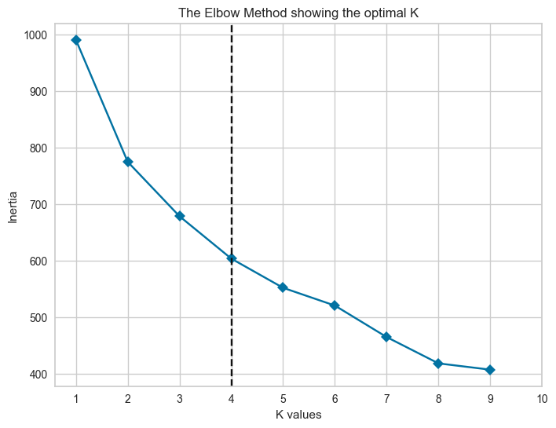

```python
from yellowbrick.cluster import KElbowVisualizer
import matplotlib.pyplot as plt
plt.rcParams['figure.figsize'] = [8, 6]

fig, ax = plt.subplots()

model = KMeans(n_clusters=k, init='random', n_init=20, random_state=1773)

visualizer = KElbowVisualizer(model, k=(1,10), timings=False, ax=ax)
visualizer.fit(songs_train_scaled) # Fit the data to the visualizer
visualizer.ax.set_ylabel('Inertia')
visualizer.ax.set_xlabel('K values')
plt.xticks([1,2,3,4,5,6,7,8,9,10])
visualizer.ax.set_title('The Elbow Method showing the optimal K');
```

```python
km4 = KMeans(n_clusters=4, init='random', n_init=20, random_state=2000)
km4.fit(songs_train_scaled)
```

```
KMeans(init='random', n_clusters=4, n_init=20, random_state=2000)
```

```python
#get the cluster labels
label_pred = km4.predict(songs_train_scaled)
label_pred
```

```
array([2, 2, 1, 2, 2, 1, 0, 1, 2, 1, 1, 0, 1, 1, 2, 1, 3, 1, 0, 2, 2, 0,
       1, 1, 0, 2, 2, 0, 2, 1, 2, 2, 1, 0, 2, 1, 2, 1, 3, 0, 2, 2, 2, 2,
       2, 2, 0, 0, 2, 2, 2, 2, 2, 2, 2, 0, 3, 0, 3, 2, 2, 2, 1, 3, 0, 1,
       1, 2, 2, 2, 0, 0, 1, 0, 2, 1, 2, 2, 0, 2, 0, 2, 2, 0, 2, 2, 0, 1,
       1, 2])
```

```python
#count the number of elements in each cluster
pd.Series(km4.labels_).value_counts()
```

```
2    43
1    22
0    20
3     5
dtype: int64
```

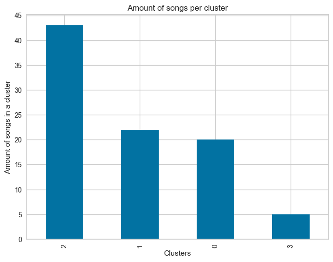

```python
songs_train_scaled['cluster'] = label_pred

songs_train_scaled['cluster'].value_counts().plot(kind='bar')
plt.yticks([0,5,10,15,20,25,30,35,40,45])
plt.xlabel('Clusters')
plt.ylabel('Amount of songs in a cluster')
plt.title('Amount of songs per cluster')
plt.show()
```

Above graph shows the number of the songs in eachg cluster. As we can see, third cluster (2) has the most songs with 43 songs.

```python
cl1 = songs_train_scaled.loc[songs_train_scaled['cluster'] == 0]
cl1
```

| song name | danceability | energy | loudness | speechiness | acousticness | instrumentalness | liveness | valence | tempo | duration_ms | time_signature | cluster |
| --- | --- | --- | --- | --- | --- | --- | --- | --- | --- | --- | --- | --- |
| Snow On The Beach (feat. Lana Del Rey) | 1.143400 | -1.842907 | -2.292792 | -0.379378 | 2.101964 | -0.564795 | -0.465542 | -1.156550 | -0.456894 | 0.049158 | 0.174741 | 0 |
| This Love (Taylor’s Version) | -0.327775 | -1.026292 | -0.605423 | -0.419435 | 0.585456 | -0.569139 | -0.989763 | -1.780384 | 0.887519 | -0.020300 | 0.174741 | 0 |
| Lavender Haze | 1.692232 | -1.259610 | -1.253493 | 0.096685 | 0.202420 | -0.563890 | 0.092364 | -1.576285 | -0.966502 | -0.570335 | 0.174741 | 0 |
| ivy | 0.015245 | -0.788306 | -0.817704 | -0.413273 | 2.746871 | -0.569053 | -0.727652 | 0.360887 | -1.289252 | 0.098922 | 0.174741 | 0 |
| cowboy like me | 0.693663 | -0.918965 | -0.725423 | -0.422517 | 2.406829 | -0.568461 | -0.402383 | 0.254400 | 0.253536 | 0.267263 | 0.174741 | 0 |
| Bir Daha | 1.318722 | -1.996898 | -1.334195 | -0.487224 | 1.511777 | -0.182001 | -0.276064 | -1.422766 | -0.061483 | 0.392019 | 0.174741 | 0 |
| Mastermind | 1.135778 | -1.665585 | -2.497353 | 1.415487 | 1.566496 | -0.563496 | -0.816075 | -1.462699 | 0.174604 | -0.701283 | 0.174741 | 0 |
| Maroon | 1.105287 | -1.567591 | -0.474897 | -0.373216 | -0.363144 | -0.569139 | -0.669756 | -1.843389 | -0.532749 | -0.387293 | 0.174741 | 0 |
| Sweet Nothing | -1.364458 | -2.580195 | -2.781914 | -0.177552 | 3.184626 | -0.568933 | -0.486595 | -0.255849 | 2.177732 | -0.730593 | 0.174741 | 0 |
| The Dream Synopsis - The Dream Synopsis EP Version | 0.335397 | -1.572258 | -0.658055 | -0.511875 | 0.941132 | -0.536593 | -0.486595 | -0.313530 | -0.408217 | -0.342187 | 0.174741 | 0 |
| There’d Better Be A Mirrorball | 0.000000 | -1.609589 | -1.386827 | -0.484143 | 1.883087 | -0.508334 | 0.260789 | -0.632990 | -1.951715 | 0.160701 | 0.174741 | 0 |
| Telescope | 0.579323 | -1.086955 | 0.752823 | -0.518037 | 0.472109 | -0.569081 | -0.659230 | -1.231978 | -1.103381 | -0.271738 | 0.174741 | 0 |
| Vigilante Shit | 2.172461 | -2.038895 | -1.455949 | 5.051437 | 0.081256 | -0.568909 | -0.423436 | -1.289658 | -1.644664 | -1.003812 | 0.174741 | 0 |
| You're On Your Own, Kid | 1.394948 | -1.483597 | -1.172792 | 0.053546 | 0.972400 | -0.569116 | -0.381329 | -0.326840 | -0.059116 | -0.664756 | 0.174741 | 0 |
| Nothing New (feat. Phoebe Bridgers) (Taylor’s Version) (From The Vault) | 0.708908 | -1.572258 | -0.880160 | -0.533444 | 2.598347 | -0.569139 | -0.076060 | -0.034002 | -0.772347 | 0.080163 | 0.174741 | 0 |
| Question...? | 1.814195 | -0.988961 | -0.642265 | 1.538739 | 0.288408 | -0.569139 | 1.429234 | -1.515942 | -0.495078 | -0.476237 | 0.174741 | 0 |
| Labyrinth | -0.198189 | -1.870906 | -2.978055 | -0.206825 | 2.496725 | 0.953168 | -0.391856 | -1.387271 | -0.453659 | -0.044951 | 0.174741 | 0 |
| Midnight Rain | 0.990947 | -1.637587 | -1.681213 | 0.224559 | 2.101964 | -0.568913 | -0.486595 | -0.992382 | 0.722869 | -0.888718 | 0.174741 | 0 |
| Carolina - From The Motion Picture “Where The Crawdads Sing” | -0.282039 | -2.449536 | -2.396651 | -0.450248 | 2.938389 | -0.569119 | 0.976593 | -0.575309 | -0.224397 | 0.145031 | 0.174741 | 0 |
| mirrorball | 0.274416 | -1.385603 | -1.093844 | -0.417895 | 2.086330 | -0.569131 | -1.061343 | -0.473260 | -0.449793 | -0.494501 | 0.174741 | 0 |

```python
cl2 = songs_train_scaled.loc[songs_train_scaled['cluster'] == 1]
cl2
```

| song name | danceability | energy | loudness | speechiness | acousticness | instrumentalness | liveness | valence | tempo | duration_ms | time_signature | cluster |
| --- | --- | --- | --- | --- | --- | --- | --- | --- | --- | --- | --- | --- |
| Damage, Inc. | -1.425439 | 0.625605 | -1.270335 | 1.615772 | -0.593094 | 1.469352 | -0.286591 | -1.378397 | -1.178211 | 0.929383 | 0.174741 | 1 |
| The Call Of Ktulu - Remastered | -1.547402 | 0.989583 | -0.222265 | 0.574288 | -0.506586 | 3.179760 | 0.513426 | -1.311843 | 0.689222 | 3.247270 | 0.174741 | 1 |
| The Day That Never Comes | -1.364458 | 1.250900 | 1.632823 | -0.003458 | -0.594563 | 0.082653 | -0.581334 | 0.210030 | 0.210776 | 2.587445 | 0.174741 | 1 |
| Dangerous Animals | -1.318722 | 0.970917 | 0.616682 | 1.816058 | -0.544499 | -0.569129 | 0.681850 | 0.347576 | 0.150818 | -0.474969 | 0.174741 | 1 |
| What If You Were Right The First Time? | -1.943781 | 1.232234 | 0.871068 | 1.184388 | -0.594733 | -0.473339 | -1.219241 | -0.384521 | 0.959587 | -0.794897 | 0.174741 | 1 |
| Battery | -0.243925 | 0.998916 | -0.649984 | 0.078197 | -0.594059 | 1.871801 | -0.581334 | -0.118304 | -0.979874 | 0.697569 | 0.174741 | 1 |
| Confusion | -0.503096 | 1.288231 | 1.120893 | 0.027355 | -0.594804 | -0.418658 | -0.381329 | -0.459949 | 0.029520 | 1.722209 | 0.174741 | 1 |
| Ode To The Mets | -0.663172 | -0.452327 | 0.534577 | -0.511875 | 0.737888 | 0.222635 | -0.633966 | -1.121054 | -1.165154 | 1.152169 | 0.174741 | 1 |
| Pretty Visitors | -2.050498 | 0.849592 | 0.480893 | 6.191523 | -0.354936 | -0.569015 | -0.360276 | -1.382834 | -1.506286 | -0.361512 | 0.174741 | 1 |
| The Outlaw Torn | 0.808003 | 0.046975 | 0.057384 | -0.470277 | -0.593958 | -0.313672 | 1.587132 | -0.038439 | -0.119548 | 3.883436 | 0.174741 | 1 |
| The Jeweller's Hands | -0.022868 | 0.401619 | -0.410335 | -0.205284 | -0.059451 | -0.204310 | -0.455015 | -0.278034 | -0.970565 | 1.062995 | 0.174741 | 1 |
| Ize of the World | -0.884230 | 0.840259 | 1.350016 | -0.242260 | -0.594884 | 2.239255 | -0.805549 | -0.783846 | 0.530686 | 0.160413 | 0.174741 | 1 |
| King Nothing | 0.106717 | 0.900922 | 0.412121 | -0.376297 | -0.594591 | -0.536112 | -0.759232 | -0.397832 | -0.372794 | 0.898194 | 0.174741 | 1 |
| Ride The Lightning - Remastered | -1.951403 | 1.218235 | 0.287209 | 1.739025 | -0.594682 | -0.131695 | 0.639744 | -0.788283 | 1.095520 | 1.673333 | 0.174741 | 1 |
| Blackened | -0.518341 | 0.410952 | -0.708230 | 0.937883 | -0.594676 | -0.560303 | -0.518174 | 0.201156 | 0.295744 | 1.715141 | 0.174741 | 1 |
| Murder One | -0.434492 | 1.092243 | 1.175981 | -0.331618 | -0.594834 | -0.558116 | -0.581334 | -0.504318 | -0.553182 | 1.077108 | 0.174741 | 1 |
| Fear of Sleep | -0.586945 | 0.975584 | 0.878086 | -0.046596 | -0.593817 | 3.031029 | 2.050299 | -0.806031 | 0.244227 | -0.131370 | 0.174741 | 1 |
| The Judas Kiss | -1.448307 | 1.148240 | 1.485805 | 0.300051 | -0.591769 | -0.491711 | -1.286611 | 0.218904 | 2.280056 | 2.639250 | 0.174741 | 1 |
| City of Delusion | -1.737968 | 0.938253 | 0.627559 | 0.184502 | -0.584444 | -0.447092 | -0.255011 | -0.641864 | -0.067952 | 0.419761 | 0.174741 | 1 |
| Atlas, Rise! | -0.739399 | 1.306896 | 1.260542 | -0.018864 | -0.594805 | -0.438343 | -0.956078 | -0.087245 | -1.038807 | 1.576917 | 0.174741 | 1 |
| All The Time | -0.838494 | 0.788929 | 0.313174 | 0.190665 | -0.594589 | 2.274250 | -0.370803 | -1.666799 | 0.804918 | -0.812734 | 0.174741 | 1 |
| Leper Messiah - Remastered | -1.021438 | 0.438950 | -0.581914 | 0.096685 | -0.594715 | 2.904170 | 1.692397 | 0.458499 | 0.676678 | 1.014879 | 0.174741 | 1 |

```python
cl3 = songs_train_scaled.loc[songs_train_scaled['cluster'] == 2]
cl3
```

| song name | danceability | energy | loudness | speechiness | acousticness | instrumentalness | liveness | valence | tempo | duration_ms | time_signature | cluster |
| --- | --- | --- | --- | --- | --- | --- | --- | --- | --- | --- | --- | --- |
| I Can't Win | -0.312529 | 0.149635 | 0.747560 | -0.462574 | -0.572211 | 2.331118 | -0.645545 | -0.224791 | -0.950644 | -1.035647 | 0.174741 | 2 |
| Little Girl (feat. Julian Casablancas) | 0.205812 | 0.924254 | 0.445103 | -0.377838 | -0.594497 | -0.556103 | -0.286591 | 1.709719 | 0.966175 | 0.242969 | 0.174741 | 2 |
| Holy Ground (Taylor's Version) | 0.830871 | 0.443617 | 0.464402 | 0.025815 | -0.482354 | -0.559603 | -0.549754 | 0.254400 | 1.394602 | -0.563832 | 0.174741 | 2 |
| Enter Sandman | 0.487851 | 0.532278 | -0.612090 | -0.498009 | -0.586594 | -0.519270 | -1.085554 | 0.667036 | 0.067743 | 0.915570 | 0.174741 | 2 |
| She's Thunderstorms | -0.060981 | 0.858924 | 0.715981 | -0.450248 | -0.592895 | -0.558815 | 0.123944 | 1.230528 | -0.102981 | -0.195328 | 0.174741 | 2 |
| Life Is Simple in the Moonlight | 0.015245 | -0.083684 | 0.382296 | -0.474899 | -0.545672 | -0.567630 | -0.732916 | 0.263274 | 0.526742 | 0.038965 | 0.174741 | 2 |
| Razorblade | -0.907098 | 0.676936 | 1.086156 | -0.326996 | -0.587063 | 0.450107 | -0.644493 | 0.254400 | 0.573367 | -0.504186 | 4.106409 | 2 |
| Selfless | 0.190567 | -0.163012 | 0.929665 | -0.444086 | 0.151609 | -0.561484 | -0.761337 | -1.618879 | 0.017765 | -0.343225 | 0.174741 | 2 |
| Cornerstone | -1.722723 | 0.032976 | 0.398788 | -0.360890 | -0.565058 | -0.569139 | 1.755556 | 1.372511 | 1.882081 | -0.621333 | 0.174741 | 2 |
| Welcome To Japan | 1.463552 | -0.223675 | -0.099458 | -0.490305 | -0.585812 | -0.503960 | 0.134471 | 0.853388 | 0.098314 | -0.242521 | 0.174741 | 2 |
| One Way Trigger | 0.022868 | 1.064245 | 0.994226 | -0.402488 | -0.594208 | 1.460603 | -0.476068 | 2.264337 | -1.007605 | -0.110316 | 0.174741 | 2 |
| Do Me a Favour | -0.335397 | 0.112304 | 0.108261 | -0.003458 | -0.594411 | -0.316734 | -0.876076 | 0.755775 | 2.311968 | -0.491273 | 0.174741 | 2 |
| 50/50 | -0.167699 | 1.008248 | 0.187559 | -0.422517 | -0.594754 | 2.108021 | 0.608164 | 0.751338 | -0.852659 | -1.021960 | 0.174741 | 2 |
| Harvester Of Sorrow | 1.105287 | 0.597607 | -0.668230 | -0.345484 | -0.594110 | -0.231869 | 1.629238 | 0.840077 | -1.121250 | 1.082065 | 0.174741 | 2 |
| Science Fiction | 0.221057 | 0.242963 | 0.538788 | -0.522659 | -0.479618 | -0.218309 | 2.471361 | 0.840077 | -1.320573 | -0.760456 | 0.174741 | 2 |
| Gratisfaction | 0.998570 | 0.345623 | 0.669314 | -0.097438 | -0.416690 | 0.918172 | 0.797642 | 1.128478 | 0.548201 | -0.837789 | 0.174741 | 2 |
| Slow Animals | 1.151023 | -0.317002 | -0.346476 | -0.519578 | -0.337738 | 0.655706 | -0.692915 | 0.205593 | 0.412347 | 0.101839 | 0.174741 | 2 |
| Two Kinds of Happiness | 0.160076 | 0.298959 | 0.594577 | -0.259207 | -0.588939 | -0.459778 | 0.155524 | 1.350326 | 0.636679 | -0.343375 | 0.174741 | 2 |
| Batphone | 1.234872 | -0.153679 | 0.427559 | -0.408651 | 0.624541 | -0.569139 | 1.502920 | 0.982059 | -0.592432 | 0.227749 | 0.174741 | 2 |
| Chances | 0.365888 | -0.676313 | -0.959809 | -0.511875 | 0.831693 | 2.103647 | -0.549754 | 0.338702 | -0.703513 | -0.404404 | 0.174741 | 2 |
| Karma | 0.983324 | -0.438328 | -0.050686 | 0.068953 | -0.308033 | -0.569139 | 3.387169 | -1.582940 | -1.243337 | -0.542017 | 0.174741 | 2 |
| Between Love & Hate | -0.442115 | -0.517657 | 0.711419 | -0.564257 | -0.594671 | 1.749317 | -0.680283 | 0.378634 | -0.684815 | -0.637475 | 0.174741 | 2 |
| Piledriver Waltz | -0.533587 | 0.704934 | 0.841945 | -0.354728 | -0.566621 | -0.568632 | 3.229271 | 0.090233 | -0.454882 | -0.553224 | 0.174741 | 2 |
| Ronnie | 0.312529 | 0.919587 | 0.520191 | -0.436382 | -0.590620 | -0.555753 | -1.126608 | 0.702531 | -1.462106 | 0.752602 | 0.174741 | 2 |
| The Very First Night (Taylor's Version) (From The Vault) | 1.257740 | 0.088972 | 0.674226 | -0.524200 | -0.590424 | -0.569139 | -0.602387 | 0.564986 | -0.020932 | -0.594733 | 0.174741 | 2 |
| Take It Or Leave It | -0.640304 | 0.980250 | 0.286156 | -0.331618 | -0.592801 | 0.975040 | -0.602387 | 0.134602 | 1.284547 | -0.652926 | 0.174741 | 2 |
| My Propeller | -0.747022 | -0.265672 | 0.066156 | -0.502631 | -0.391676 | -0.327670 | 0.755536 | 1.048613 | -0.228302 | -0.531697 | 0.174741 | 2 |
| When It Started | 1.486420 | -0.345001 | -0.503318 | -0.434842 | 0.409572 | -0.543942 | -0.286591 | 2.073548 | 0.413255 | -0.891600 | 0.174741 | 2 |
| Machu Picchu | 1.387326 | 0.480948 | 0.579840 | 0.058168 | -0.543327 | -0.144818 | -1.064501 | 1.865012 | -0.651877 | -0.486960 | 0.174741 | 2 |
| Bigger Boys and Stolen Sweethearts | -0.144831 | -0.592319 | -0.132090 | -0.457952 | -0.574673 | -0.569139 | -0.758179 | 0.671473 | 0.403709 | -0.821185 | 0.174741 | 2 |
| Mardy Bum | 0.922343 | -0.536322 | 0.526156 | -0.394785 | -0.482354 | -0.569139 | 0.376581 | -0.628553 | -0.367824 | -0.881142 | 0.174741 | 2 |
| Soma | -0.091472 | 0.004977 | -0.152791 | -0.493387 | -0.292399 | -0.542761 | -1.009763 | 0.214467 | 1.082068 | -1.130551 | 0.174741 | 2 |
| Don't Sit Down 'Cause I've Moved Your Chair | -0.602191 | 0.924254 | 0.631068 | -0.262288 | -0.520266 | 0.646957 | 1.734503 | -0.615242 | -0.071423 | -0.788128 | 0.174741 | 2 |
| Bejeweled | 1.425439 | -0.764975 | -0.766125 | 0.048924 | -0.336566 | -0.568693 | -0.739232 | -0.184858 | 1.675027 | -0.665228 | 0.174741 | 2 |
| Crying Lightning | -0.114340 | 0.798261 | 0.885454 | -0.246882 | -0.537073 | -0.567346 | 0.818695 | 0.959874 | -0.584621 | -0.311702 | 0.174741 | 2 |
| One Point Perspective | 1.532156 | -0.601651 | 0.833875 | -0.311589 | -0.372133 | -0.549717 | -0.181325 | 1.723029 | -1.752826 | -0.498341 | 0.174741 | 2 |
| Tranquility Base Hotel & Casino | 0.541209 | 0.564943 | 0.919489 | -0.499549 | -0.434279 | -0.504835 | 0.397634 | 1.452376 | 0.814977 | -0.458527 | 0.174741 | 2 |
| The Bad Thing | 0.282039 | 1.110909 | 1.160893 | 0.198368 | -0.590893 | -0.569139 | 1.008173 | 0.374197 | -0.413148 | -1.229665 | 0.174741 | 2 |
| Happy Ending | 0.861362 | 0.546277 | -0.279458 | -0.388622 | -0.572602 | -0.486900 | 2.039773 | -0.881459 | -0.297451 | -0.918961 | 0.174741 | 2 |
| From The Ritz To The Rubble | -2.263933 | 0.784262 | 0.621244 | -0.280776 | -0.589174 | -0.569139 | 1.545026 | 0.897757 | 2.672350 | -0.673749 | 0.174741 | 2 |
| Electricityscape | -0.998570 | 0.784262 | 0.975630 | -0.296183 | -0.586320 | 0.060781 | -0.880287 | 0.516180 | 0.729536 | -0.445763 | 0.174741 | 2 |
| Taken for a Fool | 0.426869 | 0.821593 | 0.877033 | -0.095897 | -0.571663 | -0.520145 | 0.681850 | 1.913818 | 0.611591 | -0.560603 | 0.174741 | 2 |
| The Great War | 0.457360 | 0.126303 | -0.715949 | -0.413273 | 0.261048 | -0.569042 | -0.810812 | 0.445189 | -1.006816 | -0.132650 | 0.174741 | 2 |

```python
cl4 = songs_train_scaled.loc[songs_train_scaled['cluster'] == 3]
cl4
```

| song name | danceability | energy | loudness | speechiness | acousticness | instrumentalness | liveness | valence | tempo | duration_ms | time_signature | cluster |
| --- | --- | --- | --- | --- | --- | --- | --- | --- | --- | --- | --- | --- |
| I Bet You Think About Me (feat. Chris Stapleton) (Taylor’s Version) (From The Vault) | -0.929966 | 0.004977 | 0.852823 | -0.194499 | 0.057805 | -0.569139 | 0.229209 | 0.085796 | 1.109010 | 0.383337 | -3.756927 | 3 |
| American Sports | -1.074796 | 0.704934 | 0.932823 | -0.166768 | -0.588314 | -0.556322 | -0.360276 | 0.622666 | 2.175444 | -1.081767 | -3.756927 | 3 |
| Red Light | 0.160076 | 0.574275 | 1.055630 | -0.330077 | -0.594266 | 2.269876 | 0.292369 | 1.993683 | -0.710297 | -0.693742 | -3.756927 | 3 |
| Metabolism | -0.693663 | 0.634938 | 0.635981 | -0.348565 | -0.594757 | -0.552910 | 0.029205 | -0.504318 | 1.596173 | -0.820724 | -3.756927 | 3 |
| One | -0.579323 | -0.088350 | -0.877353 | -0.006539 | -0.590581 | -0.194249 | -0.391856 | -0.180421 | -0.763747 | 2.255064 | -3.756927 | 3 |

```python
cl1_mean = cl1.groupby('cluster').mean()
cl2_mean = cl2.groupby('cluster').mean()
cl3_mean = cl3.groupby('cluster').mean()
cl4_mean = cl4.groupby('cluster').mean()
```

```python
frames = [cl1_mean, cl2_mean, cl3_mean, cl4_mean]
cluster_means = pd.concat(frames)
cluster_means
```

| cluster | danceability | energy | loudness | speechiness | acousticness | instrumentalness | liveness | valence | tempo | duration_ms | time_signature |
| --- | --- | --- | --- | --- | --- | --- | --- | --- | --- | --- | --- |
| 0 | 0.660123 | -1.567125 | -1.318809 | 0.129270 | 1.540172 | -0.468161 | -0.302065 | -0.882790 | -0.332649 | -0.270172 | 0.174741 |
| 1 | -0.924075 | 0.830078 | 0.420989 | 0.578630 | -0.491846 | 0.525610 | -0.130320 | -0.486974 | 0.000699 | 1.085545 | 0.174741 |
| 2 | 0.238253 | 0.261628 | 0.337547 | -0.331833 | -0.410994 | -0.060406 | 0.211853 | 0.612833 | 0.075140 | -0.430714 | 0.266175 |
| 3 | -0.623534 | 0.366155 | 0.519981 | -0.209290 | -0.462023 | 0.079451 | -0.040270 | 0.403481 | 0.681317 | 0.008434 | -3.756927 |

We can use the SilhouetteVisualizer to evaluate our clustering method.

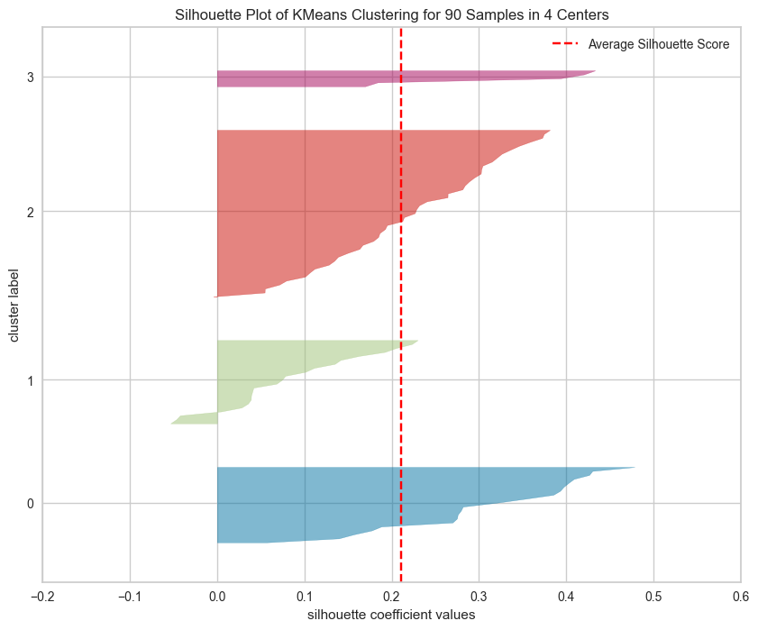

```python
# Import SilhouetteVisualizer
from yellowbrick.cluster import SilhouetteVisualizer
import warnings
warnings.filterwarnings('ignore')
import matplotlib.pyplot as plt
plt.rcParams['figure.figsize'] = [10, 8]

fig, ax = plt.subplots()

visualizer = SilhouetteVisualizer(km4, colors='yellowbrick', ax=ax)
visualizer.fit(songs_train_scaled.drop(['cluster'], axis=1))
#visualizer.ax.set_ylabel('Cluster Label')
#visualizer.ax.set_title('Silhoutte Coefficient Values');
visualizer.show();
```

- In this graph x axis shows the silhouette values, and the y axis shows the cluster labels. and the
- Height of each silhouette indicates the number of points in the corresponding cluster.
- The red line shows the average silhouette value for all clusters. In this example, the average value is between 0.2 and 0.3 but much closer to 0.2.
- Data points with a large (almost 1) silhouette values are very well clustered, while data points with a negative silhouette values are probably placed in the wrong cluster.
- If the average silhouette value is close to 1, that means the separation of the clusters are well-done. In our case, average silhouette value is closer to 0.2. This model can be improved by using different clustering algorithms and the silhouette value would ideally be close to 1.

## Methodologies

### PCA for visualization only

```python
#instantiate the pca object
from sklearn.decomposition import PCA

#instantiate the pca class
pca = PCA(n_components=2)
songs_pca = pca.fit_transform(songs_train_scaled)
```

```python
songs_pca
```

| song name | pca0 | pca1 |
| --- | --- | --- |
| I Can't Win | -0.975592 | 0.207633 |
| Little Girl (feat. Julian Casablancas) | -1.658445 | -1.022974 |
| Damage, Inc. | 0.251225 | 3.102889 |
| Holy Ground (Taylor's Version) | -0.784488 | -0.914641 |
| Enter Sandman | -0.457411 | -0.381965 |
| ... | ... | ... |
| Taken for a Fool | -1.769908 | -1.557908 |
| mirrorball | 3.101909 | -0.282821 |
| All The Time | -0.716630 | 1.792563 |
| Leper Messiah - Remastered | -1.170397 | 1.567912 |
| The Great War | 0.449930 | -0.829213 |

90 rows × 2 columns

```python
km4_pca = KMeans(n_clusters=4, init='random', n_init=20, random_state=1773)
km4_pca.fit(songs_pca)
```

```
KMeans(init='random', n_clusters=4, n_init=20, random_state=1773)
```

```python
label_pca = km4_pca.predict(songs_pca)
```

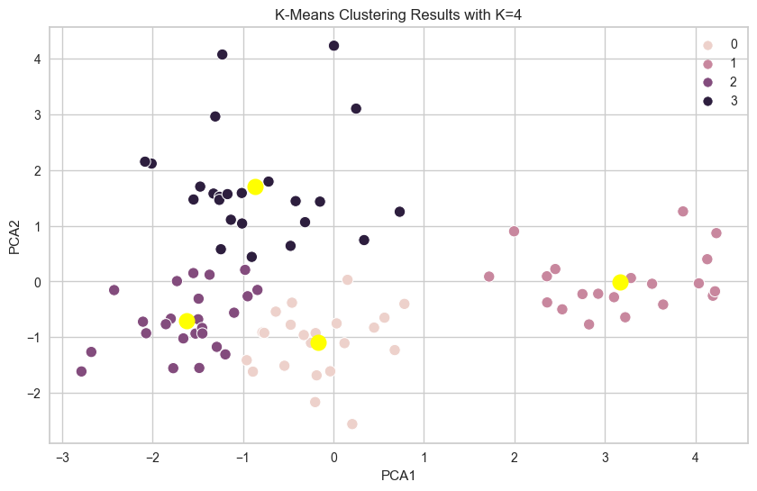

```python
import matplotlib.pyplot as plt
import seaborn as sns
plt.rcParams['figure.figsize'] = [10, 6]

sns.scatterplot(data=songs_pca, x=songs_pca.pca0, y=songs_pca.pca1, hue=label_pca, s=80)
plt.scatter(km4_pca.cluster_centers_[:,0], km4_pca.cluster_centers_[:,1], marker='o', s=100, c='yellow', linewidth=3)
plt.title('K-Means Clustering Results with K=4')
plt.xlabel('PCA1')
plt.ylabel('PCA2')
plt.show();
```

Above is a graph that visualizes the clusters. There are 4 different clusters here.

### Song Recommendation

```python
songs_test_scaled
```

| song name | danceability | energy | loudness | speechiness | acousticness | instrumentalness | liveness | valence | tempo | duration_ms | time_signature |
| --- | --- | --- | --- | --- | --- | --- | --- | --- | --- | --- | --- |
| tolerate it | -1.501666 | -1.646920 | -1.205072 | -0.205284 | 2.836767 | -0.569022 | -0.858181 | -1.032315 | -1.837715 | -0.074030 | 4.106409 |
| Anti-Hero | 0.952834 | -0.372999 | 0.127910 | -0.253044 | -0.075085 | -0.569134 | -0.097113 | 0.289895 | -0.969855 | -0.590005 | 0.174741 |
| Teddy Picker | 0.945211 | 1.162239 | 0.642296 | 0.401735 | -0.593801 | -0.565250 | -1.224505 | 1.638727 | 1.126603 | -1.001517 | 0.174741 |
| Knee Socks | 1.158646 | -0.802306 | -0.482967 | -0.448708 | -0.114170 | -0.556409 | 1.902928 | 0.591608 | -0.929540 | 0.065750 | 0.174741 |
| Why'd You Only Call Me When You're High? | 1.356835 | -0.386998 | 0.164402 | -0.390163 | -0.406137 | -0.569090 | -0.602387 | 1.536678 | -1.165075 | -1.046208 | 0.174741 |
| For Whom The Bell Tolls - Remastered | 0.038113 | 0.672269 | 0.280542 | 0.078197 | -0.572914 | -0.553872 | -1.067659 | -0.908080 | -0.143689 | 0.670046 | 0.174741 |
| Tap Out | 1.707478 | 0.144969 | 0.351770 | -0.416354 | -0.526129 | 1.097524 | 1.523973 | 0.777960 | -0.218953 | -0.340147 | 0.174741 |
| Halo On Fire | -1.448307 | 1.036247 | 1.204402 | -0.180633 | -0.594863 | -0.550023 | -0.662388 | -1.081121 | 0.190422 | 2.803635 | 0.174741 |
| At The Door | -0.434492 | -1.824242 | 0.064051 | -0.467196 | 2.758597 | -0.529200 | -0.160272 | -0.402268 | -0.182899 | 0.674658 | 0.174741 |
| Call Me Back | 1.699855 | -1.945568 | -0.947879 | -0.417895 | 2.778139 | -0.569074 | -1.056080 | -1.192045 | 0.167267 | -0.805193 | 0.174741 |

```python
import random
from sklearn.metrics.pairwise import euclidean_distances
def get_recommendation(song_name):
        features = songs_test_scaled.loc[song_name]
        song_features = pd.DataFrame(features).transpose()
        ed1 = euclidean_distances(song_features, cl1_mean)
        ed2 = euclidean_distances(song_features, cl2_mean)
        ed3 = euclidean_distances(song_features, cl3_mean)
        ed4 = euclidean_distances(song_features, cl4_mean)
        c = min(ed1, ed2, ed3, ed4)
        if c == ed1:
            cl1_list = cl1.index.values.tolist()
            print(random.choices(cl1_list, k = 5))
        elif c == ed2:
            cl2_list = cl2.index.values.tolist()
            print(random.choices(cl2_list, k = 5))
        elif c == ed3:
            cl3_list = cl3.index.values.tolist()
            print(random.choices(cl3_list, k = 5))
        else:
            cl4_list = cl4.index.values.tolist()
            print(random.choices(cl4_list, k = 5))
```

#### Getting the song recommendations:

```python
get_recommendation('tolerate it')
```

```
['Bir Daha', 'Labyrinth', 'Carolina - From The Motion Picture “Where The Crawdads Sing”', 'Telescope', 'Telescope']
```

```python
get_recommendation('Anti-Hero')
```

```
['Slow Animals', 'My Propeller', 'Take It Or Leave It', 'Soma', 'Harvester Of Sorrow']
```

```python
get_recommendation('Teddy Picker')
```

```
['Gratisfaction', "Don't Sit Down 'Cause I've Moved Your Chair", '50/50', 'Razorblade', 'Bejeweled']
```

## Conclusion

- In this project, we wanted to build a song recommendation system.
- To start off, we did literature review for our project topic.
- We then collected the data from Beyza's Spotify account using the Spotify API.
- We performed some data exploration and data visualization.
- Then, we prepared the data before using it for the methodology.
- We splitted the data set into 4 different clusters by using the K-Means Clustering Algorithm with k=4.
- We performed PCA to be able to visualize our clusters in plane.
- We defined a function that calculates the Euclidian Distance between a (user-input) song and the cluster means for each cluster and that finds the closest cluster for that song.
- Then we recommended 5 random songs from that cluster.

## Work Distribution

- Task 1: Literature Review - Beyza %20 & Melike %80
- Task 2: Data Manipulation - Beyza %100
- Task 3: Doing researches on the methodologies - Beyza %50 & Melike %50
- Task 4: Exploratory Data Analysis - Melike %100
- Task 5: Model Construction - Beyza %100
- Task 6: Conclusion on the result - Beyza %50 & Melike %50
- Task 7: Presentation - Beyza %50 & Melike %50

## References

- https://developer.spotify.com/documentation/web-api/reference/get-audio-features
- https://developer.spotify.com/documentation/web-api
- https://www.linkedin.com/advice/0/how-do-you-choose-between-collaborative-content-based

- https://scikit-learn.org/stable/modules/generated/sklearn.metrics.pairwise.euclidean_distances.html
- https://seaborn.pydata.org/generated/seaborn.heatmap.html
- https://www.scikit-yb.org/en/latest/api/cluster/elbow.html
- https://scikit-learn.org/stable/modules/generated/sklearn.cluster.KMeans.html